# Happy Structured Logging in R

構造化ログ入門.R

atusy

# Atusy

- Application Engineer at [3-shake Inc.](https://3-shake.com/)
- Maitainer of R packages
  - felp, ftExtra, knitr, rmarkdown, …
- Appears on
  - Blog: https://blog.atusy.net/
  - GitHub: [@atusy](https://github.com/atusy)
  - X: [@Atsushi776](https://x.com/Atsushi776)

# Publication

[figure not shown]

# Why logging?

To record or help identifying (potential) issues and enhance improvements.

- **unexpected behaviors**, typically errors
- **performance issues**
- security issues
- auditing and compliance

The **[logger](https://daroczig.github.io/logger/index.html)** package helps you.

# Why not print?

- `print`-debugging is not suitable for long-term maintenance.
- `print`-logging lacks some features
  - generate analyzable logs
  - threshold by log level
  - control output destinations
  - distinguish program output from logging
    - typically on CLI tools
    - less important in R

Avoid reinvention with `print`, unless intentionally.

## Generate analyzable logs

- has traceable context
  - timestamp
  - log level
  - message
  - …
- has machine readable format (e.g., JSON Lines)

```json
{"time":"2024-12-03 22:38:17","level":"INFO","ns":"japanr2024","message":"Started session","session_id":"01JE6BWEWP0BAAFGPZTZ9GBNM6"}
{"time":"2024-12-03 22:38:17","level":"INFO","ns":"japanr2024","message":"Received request","session_id":"01JE6BWEWP0BAAFGPZTZ9GBNM6","trace_id":"01JE6BWEXF5F6HDD4YFZBP157F"}
{"time":"2024-12-03 22:38:17","level":"DEBUG","ns":"japanr2024","message":"Received request parameters","value":{"locations":"tokyo, london"},"session_id":"01JE6BWEWP0BAAFGPZTZ9GBNM6","trace_id":"01JE6BWEXF5F6HDD4YFZBP157F"}
{"time":"2024-12-03 22:38:17","level":"DEBUG","ns":"japanr2024","message":"Locations parsed","value":["tokyo","london"],"session_id":"01JE6BWEWP0BAAFGPZTZ9GBNM6","trace_id":"01JE6BWEXF5F6HDD4YFZBP157F"}
{"time":"2024-12-03 22:38:17","level":"DEBUG","ns":"japanr2024","message":"Processing location","value":"tokyo","span_id":"01JE6BWEXSW65DD1EC858XMZQ3","session_id":"01JE6BWEWP0BAAFGPZTZ9GBNM6","trace_id":"01JE6BWEXF5F6HDD4YFZBP157F"}
{"time":"2024-12-03 22:38:17","level":"DEBUG","ns":"japanr2024","message":"Plotting weather forecast","span_id":"01JE6BWEXSW65DD1EC858XMZQ3","session_id":"01JE6BWEWP0BAAFGPZTZ9GBNM6","trace_id":"01JE6BWEXF5F6HDD4YFZBP157F"}
```

## R-equivalent of JSON Lines

Named list of lines.

```r
list(time = "2024-12-03 22:38:17", level = "INFO", ns = "japanr2024", message = "Started session", session_id = "01JE6BWEWP0BAAFGPZTZ9GBNM6")
list(time = "2024-12-03 22:38:17", level = "INFO", ns = "japanr2024", message = "Received request", session_id = "01JE6BWEWP0BAAFGPZTZ9GBNM6", trace_id = "01JE6BWEXF5F6HDD4YFZBP157F")
list(time = "2024-12-03 22:38:17", level = "DEBUG", ns = "japanr2024", message = "Received request parameters", value = {locations = "tokyo, london"}, session_id = "01JE6BWEWP0BAAFGPZTZ9GBNM6", trace_id = "01JE6BWEXF5F6HDD4YFZBP157F")
list(time = "2024-12-03 22:38:17", level = "DEBUG", ns = "japanr2024", message = "Locations parsed", value = ["tokyo", "london"], session_id = "01JE6BWEWP0BAAFGPZTZ9GBNM6", trace_id = "01JE6BWEXF5F6HDD4YFZBP157F")
list(time = "2024-12-03 22:38:17", level = "DEBUG", ns = "japanr2024", message = "Processing location", value = "tokyo", span_id = "01JE6BWEXSW65DD1EC858XMZQ3", session_id = "01JE6BWEWP0BAAFGPZTZ9GBNM6", trace_id = "01JE6BWEXF5F6HDD4YFZBP157F")
list(time = "2024-12-03 22:38:17", level = "DEBUG", ns = "japanr2024", message = "Plotting weather forecast", span_id = "01JE6BWEXSW65DD1EC858XMZQ3", session_id = "01JE6BWEWP0BAAFGPZTZ9GBNM6", trace_id = "01JE6BWEXF5F6HDD4YFZBP157F")
```

## Threshold by log level

- For production
  - **FATAL:** when an error stops the program
  - **ERROR:** when an error is caught and program continued running
  - **WARNING:** when an unexpected behavior occurs without error
  - **INFO:** various info for debugging/monitoring purpose
- Additionally for development
  - **DEBUG:** further detailed info for debugging purpose

```r
logger::log_threshold("INFO") # DEBUG logs are ignored

logger::log_info(message = "Program started.")

params <- list(x = 1)
logger::log_debug(message = "Received parameters", value = params)
```

## Control output destinations

- console (stdout/stderr)
- file
- DB
- SaaS (e.g., Datadog, New Relic, …)

# The more about analyzable logs

Previous sections introduced some key features of logging.

Let’s dive into the content of logs.

## What is the preferred format?

Typically **JSON Lines**.

```json
{"time":"2024-12-04 21:07:28","level":"INFO","message":"Program started."}
{"time":"2024-12-04 21:07:28","level":"WARN","message":"Some warning."}
```

Then, packages parse them and outputs data frame (e.g., **jsonlite**, **yyjsonr**, **duckdb**, …).

| time | level | message |
| --- | --- | --- |
| 2024-12-04 21:07:28 | INFO | Program started. |
| 2024-12-04 21:07:28 | WARN | Some warning. |

## What about human-readable format?

The log requires self-maintained parsers…

```
2024-12-04 21:07:28 [INFO] Program started
2024-12-04 21:07:28 [WARN] Some warning.
```

## Can we use both?

YES!

- human readable logs to console
- machine readable logs to file

But you need advanced configurations.

## How to design log schema?

| key | type | desc | example |
| --- | --- | --- | --- |
| time | string | timestamp | `2024-12-03 22:38:17` |
| level | string | log level | `INFO` |
| ns | string | name of package, project, … | `japanr2024` |
| message | string | static message | `Received request` |
| value | any | value related to the message | `list(input = "tokyo")` |
| session_id | string | unique per access | `01JE6BWEWP0BAAFGPZTZ9GBNM6` |
| trace_id | string | unique per request | `01JE6BWEXF5F6HDD4YFZBP157F` |
| span_id | string | unique per task | `01JE6BWEXSW65DD1EC858XMZQ3` |
| context | list | (Optional) additional context | `list(...)` |

## Use static message and dynamic value

| key | type | desc | example |
| --- | --- | --- | --- |
| time | string | timestamp | `2024-12-03 22:38:17` |
| level | string | log level | `INFO` |
| ns | string | name of package, project, … | `japanr2024` |
| **message** | string | static message | `Received request` |
| **value** | any | value related to the message | `list(input = "tokyo")` |
| session_id | string | unique per access | `01JE6BWEWP0BAAFGPZTZ9GBNM6` |
| trace_id | string | unique per request | `01JE6BWEXF5F6HDD4YFZBP157F` |
| span_id | string | unique per task | `01JE6BWEXSW65DD1EC858XMZQ3` |
| context | list | (Optional) additional context | `list(...)` |

## Use static message and dynamic value

```r
# BAD: dynamic message
x <- 1
logger::log_info(message = glue::glue("x is {x}"))
```

```
{"time":"2024-12-07 14:08:20","level":"INFO","message":"x is 1"}
```

```r
# GOOD: static message and dynamic value are tidyverse-friendly
logger::log_info(message = "x is defined", value = x)
```

```
{"time":"2024-12-07 14:08:20","level":"INFO","message":"x is defined","value":1}
```

## Cautions for dynamic value

- do not inlude sensitive information
- do not include too large data

## Add identifiers for traceability

| key | type | desc | example |
| --- | --- | --- | --- |
| time | string | timestamp | `2024-12-03 22:38:17` |
| level | string | log level | `INFO` |
| ns | string | name of package, project, … | `japanr2024` |
| message | string | static message | `Received request` |
| value | any | value related to the message | `list(input = "tokyo")` |
| **session_id** | string | unique per access | `01JE6BWEWP0BAAFGPZTZ9GBNM6` |
| **trace_id** | string | unique per request | `01JE6BWEXF5F6HDD4YFZBP157F` |
| **span_id** | string | unique per task | `01JE6BWEXSW65DD1EC858XMZQ3` |
| context | list | (Optional) additional context | `list(...)` |

## Add identifiers for traceability

- **session_id**
  - R sessions that loads the package
  - browser sessions in Shiny app
- **trace_id**
  - function calls
  - user-interactions in Shiny app
- **span_id**
  - various tasks within the same trace_id

These keywords typically appears in observable engineering.

Identifiers are often generated by ULID or UUIDv4.

## Add context for additional information

| key | type | desc | example |
| --- | --- | --- | --- |
| time | string | timestamp | `2024-12-03 22:38:17` |
| level | string | log level | `INFO` |
| ns | string | name of package, project, … | `japanr2024` |
| message | string | static message | `Received request` |
| value | any | value related to the message | `list(input = "tokyo")` |
| session_id | string | unique per access | `01JE6BWEWP0BAAFGPZTZ9GBNM6` |
| trace_id | string | unique per request | `01JE6BWEXF5F6HDD4YFZBP157F` |
| span_id | string | unique per task | `01JE6BWEXSW65DD1EC858XMZQ3` |
| **context** | list | (Optional) additional context | `list(...)` |

## Add context for additional information

Optional data that helps analyzing the log.

For example, parent-child relationship between logs.

```javascript
{
  ...,
  "span_id": "01JDNN0EK0715J048SHYW7XZ2V",
  "context": {
    "parent_span_id": "01JDNN0F76GR0398VJ4MMGBCY7",
  }
}
```

# Recap of introduction to logging

- Logging helps identifying (potential) issues and enhances improvements
- Logs should be analyzable
  - Use structured logs with JSON Lines format
  - Design schema that increments observability

# How to log with **logger**?

```r
# Configure
logger::log_appender(logger::appender_stdout)
logger::log_formatter(logger::formatter_json)
logger::log_layout(logger::layout_json_parser(c("time", "level", "ns")))
```

```r
# Log
logger::log_info(message = "Program started.")
```

```
{"time":"2024-12-07 14:08:20","level":"INFO","ns":"global","message":"Program started."}
```

## **logger** in package

- Key points:
  - Configure **logger** with `.onLoad()`
  - Use environment variables to control the behavior
  - Use unique namespace and avoid affect other **logger**s
- Reference materials:
  - [Rのパッケージ内でloggerパッケージを使う](https://blog.atusy.net/2024/11/19/logger-in-r-package/)
  - 例: https://github.com/atusy/japanr-2024-logging/blob/main/R/zzz.R

## Demo of logging in a Shiny app

https://github.com/atusy/japanr-2024-logging

```bash
JAPANR2024_LOG_LEVEL=INFO R --no-save -e 'devtools::load_all(); run()'
JAPANR2024_LOG_LEVEL=DEBUG R --no-save -e 'devtools::load_all(); run()'
```

# Examples of log analysis

```r
logdata <- system.file("extdata/japanr2024.jsonl", package = "japanr2024") |>
  yyjsonr::read_ndjson_file() |>
  dplyr::mutate(time = clock::date_time_parse(time, "Asia/Tokyo")) |>
  dplyr::glimpse()
```

```
#> Rows: 184
#> Columns: 8
#> $ time       <dttm> 2024-12-03 22:38:17, 2024-12-03 22:38:17, 2024-12-03 22:38…
#> $ level      <chr> "INFO", "INFO", "DEBUG", "DEBUG", "DEBUG", "DEBUG", "DEBUG"…
#> $ ns         <chr> "japanr2024", "japanr2024", "japanr2024", "japanr2024", "ja…
#> $ message    <chr> "Started session", "Received request", "Received request pa…
#> $ session_id <chr> "01JE6BWEWP0BAAFGPZTZ9GBNM6", "01JE6BWEWP0BAAFGPZTZ9GBNM6",…
#> $ trace_id   <chr> NA, "01JE6BWEXF5F6HDD4YFZBP157F", "01JE6BWEXF5F6HDD4YFZBP15…
#> $ value      <list> <NULL>, <NULL>, ["tokyo, london"], <"tokyo", "london">, "t…
#> $ span_id    <chr> NA, NA, NA, NA, "01JE6BWEXSW65DD1EC858XMZQ3", "01JE6BWEXSW6…
```

## Error count

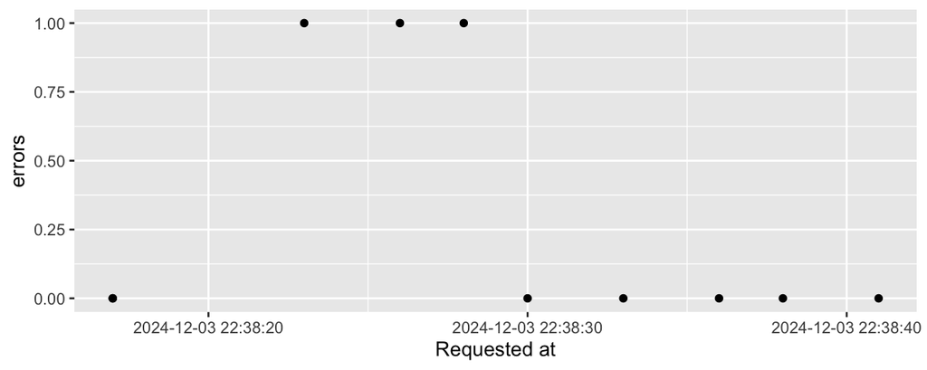

```r
logdata |>
  dplyr::summarize(
    time = min(time),
    errors = sum(level == "ERROR"),
    .by = "trace_id"
  ) |>
  ggplot2::ggplot() +
  ggplot2::aes(time, errors) +
  ggplot2::geom_point() +
  ggplot2::scale_x_datetime(name = "Requested at", date_breaks = "10 sec")
```

## Response time

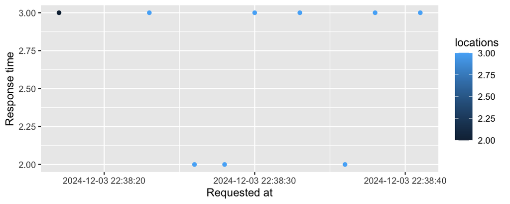

```r
logdata |>
  dplyr::reframe(
    start = min(time),
    duration = max(time) - start,
    locations = lengths(value[message == "Locations parsed"]),
    .by = "trace_id"
  ) |>
  ggplot2::ggplot() +
  ggplot2::aes(start, duration, color = locations) +
  ggplot2::geom_point() +
  ggplot2::scale_x_datetime(name = "Requested at", date_breaks = "10 sec") +
  ggplot2::scale_y_continuous(name = "Response time") +
  NULL
```

Hmm… users have to wait for several seconds…

## Deep dive into errors and slow responses.

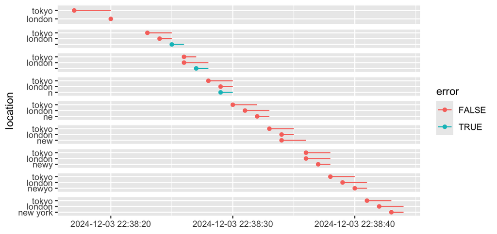

```r
logdata |>
  dplyr::filter(!is.na(span_id)) |>
  dplyr::summarize(
    start = min(time),
    end = max(time),
    location = unlist(value[message == "Processing location"]),
    error = "ERROR" %in% level,
    .by = c("trace_id", "span_id")
  ) |>
  dplyr::mutate(
    location = forcats::fct_relevel(location, rev(unique(location)))
  ) |>
  ggplot2::ggplot() +
  ggplot2::aes(
    x = start, xend = end,
    y = location, yend = location,
    color = error,
  ) +
  ggplot2::geom_point() +
  ggplot2::geom_segment() +
  ggplot2::facet_grid(rows = "trace_id", scales = "free_y") +
  ggplot2::theme(
    strip.text.y = ggplot2::element_blank(),
    axis.title.x = ggplot2::element_blank()
  ) +
  ggplot2::scale_x_datetime(name = "", date_breaks = "10 sec")
```

## Insights from the analysis

- Fast user inputs cause too many requests
  - Same locations are processed multiple times
- Invalid/unsupported locations cause errors
  - They are ignorable

# Ideas to solve the issues

- Improve performance by
  - reduceing the number of requests
    - add button to submit the request
    - slowing down a reactive expression with debounce/throttle  
      https://shiny.posit.co/r/reference/shiny/1.9.0/debounce.html
  - memoising slow functions
- Supress unimportant error logs by
  - skip obviously unimportant input (empty string or single character string)
  - handling errors with try-catch

## Memoising slow functions

```r
# Memoised versions of openmeteo functions
geocode <- memoise::memoise(openmeteo::geocode)
weather_forecast <- memoise::memoise(
  openmeteo::weather_forecast,
  # Invalidate cache daily
  hash = function(x) rlang::hash(list(x, Sys.Date()))
)

# Efficient forecast function
forecast <- function(x) {
  g <- geocode(x)
  weather_forecast(c(g$latitude, g$longitude), hourly = "temperature_2m")
}
```

## Handling errors with try-catch

```r
geocode <- function(x) {
  tryCatch(
    openmeteo::geocode(x),
    error = function(e) {
      if (e$message == "No matches found") {
        logger::log_debug("No matches found for geocode", value = x)
        return(NULL)
      }
      stop(e)
    }
  )
}
```

# ENJOY HAPPY STRUCTURED LOGGING!

- Remarks
  - Record logs to identify (potential) issues!
  - Use structured logs and analyze them with lovely tidyverse!
- References
  - Slide: https://atusy.github.io/japanr-2024-logging/
  - Repository: https://github.com/atusy/japanr-2024-logging